# Lecture 2

`inlabru` workflow

Sara Martino

sara.martino@ntnu.no

Dept. of Mathematical Science, NTNU

Janine Illian

Janine.Illian@glasgow.ac.uk

University of Glasgow

Jafet Belmont

Jafet.Belmont@glasgow.ac.uk

University of Glasgow

## `inlabru` workflow

In this lecture, we will build on your experience from the first practical and explore the key steps in an inlabru workflow.

- **Review the syntax** — Understand the general structure and workflow of `inlabru`.
- **Clarify key concepts** — Strengthen your understanding of the main modelling components.
- **Learn tips & tricks** — Discover practical strategies for fitting models efficiently and avoiding common pitfalls.

*The goal: develop a clearer understanding of how to build, fit, and troubleshoot models using `inlabru`.*

## Fitting a LGM with `inlabru`

The general workflow:

```r
# Define model components
comps <- component_1(...) +
  component_2(...) +
  ...

# Define the model predictor
pred <- linear_function(component_1,
                            component_2, ...)

# Build the observation model
lik <- bru_obs(formula = pred,
               family = ... ,
               data = ... ,
                ...)

# Fit the model
fit <- bru(comps, lik, ...)
```

## Fitting a LGM with `inlabru`

The general workflow:

```r
# Define model components
comps <- component_1(...) +
  component_2(...) +
  ...

# Define the model predictor
pred <- linear_function(component_1,
                            component_2, ...)

# Build the observation model
lik <- bru_obs(formula = pred,
               family = ... ,
               data = ... ,
                ...)

# Fit the model
fit <- bru(comps, lik, ...)
```

# Basic `component` features

## Basic `component` features

The basic syntax for components is:

```r
~ my_component_name(
  main = ...,
  model = ...
)
```

- `my_component_name`: this is a user-chosen label for the model component. This is then used as input in `predict()` and `generate()`.
- `main`: here we define the input data for the component.
- `model`: The type of model component see `?component`, and `?INLA::inla.list.models()$latent`.

**Examples**

- `beta_0(1)` or `Intercept(1)` define one intercept
- `cov_effect(altitude, model= "linear")` defines the linear effect of `altitude` on the predictor.
- `time_effect(time, model= "rw2")` defines the smooth effect of `time` on the predictor.

# Shortcuts

## Some `inlabru` shortcuts

In the slides we have fitted the model as:

```r
cmp = ~ -1 + beta0(1) + beta1(covariate, model = "linear")
formula = y ~ beta0 + beta1
lik = bru_obs(formula = formula,
              family  = "gaussian",
              data = df)
fit = bry(cmp, lik)
```

but in the practical you have

```r
cmp = ~ -1 + beta0(1) + beta1(covariate, model = "linear")

lik = bru_obs(formula = y~.,
              family  = "gaussian",
              data = df)
fit = bry(cmp, lik)
```

## Some `inlabru` shortcuts

In the slides we have fitted the model as:

```r
cmp = ~ -1 + beta0(1)+ beta1(covariate, model = "linear")
formula = y ~ beta0 + beta1
lik = bru_obs(formula = formula,
              family  = "gaussian",
              data = df)
fit = bru(cmp, lik)
```

but in the practical you have

```r
cmp = ~ -1 + beta0(1) + beta1(covariate, model = "linear")

lik = bru_obs(formula = y~.,
              family  = "gaussian",
              data = df)
fit = bru(cmp, lik)
```

1. You *don’t have to* define a formula outside of the `bru_obs()` function …it can be defined also inside the function!

```r
lik = bru_obs(formula = y~  beta0 + beta1,
              family  = "gaussian",
              data = df)
```

2. The expression `y ~ .` just means “*take all the components and sum them together*”. It also tells the `bru()` function that your predictor is *linear*.

## Why do we need the -1 in the formula?

- `inlabru` provides a dedicated term, `Intercept()`, for specifying an intercept that is shared across all data.
- When this term is omitted, a common intercept is added by default, unless the formula or component explicitly includes `-1`.

## One wrong and two correct ways of coding

```r
# This is WRONG as we get an intercept too much :-)
cmp = ~ beta0(1) + beta1(covariate, model = "linear")

lik = bru_obs(formula = y ~ . , data = df)

m1 = bru(cmp, lik)

round(m1$summary.fixed[,c(1,2)],3)
```

```
           mean     sd
beta0     0.666 22.361
beta1     0.283  0.328
Intercept 0.666 22.361
```

```r
# This is correct ...

cmp = ~ Intercept(1) + beta1(covariate, model = "linear")

lik = bru_obs(y~ ., data = df)

m1 = bru(cmp, lik)

round(m1$summary.fixed[,c(1,2)],3)
```

```
           mean    sd
Intercept 1.332 0.199
beta1     0.283 0.328
```

```r
# This is also correct
cmp = ~  -1 + beta0(1) + beta1(covariate, model = "linear")

lik = bru_obs(y~. ,data = df)

m1 = bru(cmp, lik)
round(m1$summary.fixed[,c(1,2)],3)
```

```
       mean    sd
beta0 1.332 0.199
beta1 0.283 0.328
```

# Categorical variables and interactions

## Effects of categorical variables and Interactions

`inlabru` has a specific component type for this that is called `fixed`.

Let’s look at the `iris` dataset that is in `R`

```
  Sepal.Length Sepal.Width Petal.Length Petal.Width Species
1          5.1         3.5          1.4         0.2  setosa
2          4.9         3.0          1.4         0.2  setosa
3          4.7         3.2          1.3         0.2  setosa
4          4.6         3.1          1.5         0.2  setosa
5          5.0         3.6          1.4         0.2  setosa
6          5.4         3.9          1.7         0.4  setosa
```

## Effects of categorical variables in `inlabru`

We want to fit a model where `Species` is the only covariate.

- `Species` has three categories: `setosa`, `versicolor` and `virginica`
- We want to model it as a factor effect

```r
iris$Species = factor(iris$Species)
m1 = lm(Sepal.Length ~ Species, data = iris)
m1$coef
```

```
      (Intercept) Speciesversicolor  Speciesvirginica
            5.006             0.930             1.582
```

Here *I. setosa* is our reference category!

How do we do this in `inlabru`?

## Effects of categorical variables in `inlabru`

**Option 1**: Use the `fixed` model

```r
# create the model matrix

cmp1 = ~ -1 + spp(~ Species, model = "fixed")

lik1 = bru_obs(formula = Sepal.Length ~.,
               data = iris)

fit1 = bru(cmp1, lik1)

fit1$summary.random$spp[,c(1:3)]
```

```
                 ID      mean         sd
1       (Intercept) 5.0059868 0.07268921
2 Speciesversicolor 0.9300083 0.10279807
3  Speciesvirginica 1.5820048 0.10279807
```

**Note**

- `spp(~ Species, model = "fixed")` is a `lm` style model definition! So an intercept is automatically included
- The results are stored in the `summary.random` part of the model, not the `summary.fixed`

## Effects of categorical variables in `inlabru`

- **Option 2:** Fixed effect are just random effects with fixed precision 😄

```r
cmp2 = ~ -1 +  spp(Species, model = "iid", fixed = T,initial = -6)
# or: cmp2 = ~ Intercept(1) +  spp(Species, model = "iid", fixed = T,initial = -6, constr = T)
lik2 = bru_obs(formula = Sepal.Length ~.,
               data = iris)
fit2 = bru(cmp2, lik2)
fit2$summary.random$spp$mean
```

```
[1] 5.005934 5.935922 6.587914
```

What is happening here??

This is just a re-parametrization problem

```r
c(m1$coef[1],

  m1$coef[1] + m1$coef[2],

  m1$coef[1] + m1$coef[3])
```

[output not shown]

- $\beta_0$: mean sepal length for *I. setosa*
- $\beta_0 + \beta_{0,\text{versicolor}}$ : mean sepal length for for *I. versicolor*
- $\beta_0 + \beta_{0,\text{virginica}}$: mean sepal length for for *I. virginica*

## Effects of categorical variables in `inlabru`

Alternative (and equivalent) coding options

```r
cmp1 = ~ -1 + spp(~ Species, model = "fixed")     # One reference category
cmp2 = ~ -1 + spp( ~ Species -1, model = "fixed") # No common intercept
cmp3 = ~ -1 + spp(  Species , model = "iid", fixed = T,initial = -6) # No common intercept
```

**Note**

When using the `fixed` model, `inlabru` internally creates a model matrix using the function `MatrixModels::model.Matrix()`. The syntax

```r
cmp1 = ~ -1 + spp(main = ~ Species,
                   model = "fixed")     #One reference category
```

is equivalent to

```r
cmp1 = ~ -1 + spp(main = ~ MatrixModels::model.Matrix(Species, .data.),
                   model = "fixed")     #One reference category
```

## Interactions of linear covariates in `inlabru`

Here the easiest option is to use again the `fixed` model type.

Say we want to fit a model with interactions between (**categorical**) `Species` and and (**continuous**) `Petal.Length`.

- `lm`
- `inlabru`

```r
m2 = lm(Sepal.Length ~ Species * Petal.Length, data = iris)
m2$coefficients
```

```
                   (Intercept)              Speciesversicolor
                     4.2131682                     -1.8056451
              Speciesvirginica                   Petal.Length
                    -3.1535091                      0.5422926
Speciesversicolor:Petal.Length  Speciesvirginica:Petal.Length
                     0.2859884                      0.4534460
```

```r
cmp = ~ -1 + fixed_effects( ~ ( Species * Petal.Length), model = "fixed")
lik = bru_obs(formula = Sepal.Length ~ .,
              data = iris)
fit = bru(cmp, lik)
fit$summary.random$fixed_effects$mean
```

```
[1]  4.2116296 -1.8037483 -3.1512099  0.5433309  0.2848670  0.4522720
```

```r
fit$summary.random$fixed_effects$sd
```

```
[1] 0.4066568 0.5973284 0.6329053 0.2762481 0.2944991 0.2895898
```

## Interactions of linear covariates in `inlabru`

We can also use the idea that “fixed effects are just random effects with fixed precision” 😄

**NOTE:** This idea can be very useful in more complex contexts where the `fixed` model does not work (for example if one wants to have spatially varying effect of a covariate!)

Let’s look at the interaction between (**categorical**) `Species` and (**continuous**) `Petal.Length`.

$$\begin{aligned}
\eta_i & = \beta_0 + \beta_{0,\text{Species}_i} + \beta_1x_i + \beta_{1,\text{Species}_i} x_i\\
&\class{fragment}{= \beta^*_{0,\text{Species}_i} + (\beta_1 + \beta_{1,\text{Species}_i}) x_i} \\
& \class{fragment}{= \beta^*_{0,\text{Species}_i} +\beta^*_{1,\text{Species}_i} x_i }\\
& \class{fragment}{=\underbrace{\beta^*_{0,\text{Species}_i}}_{\text{iid}} + \underbrace{\beta^*_{1,\text{Species}_i}}_{\text{iid}} \underbrace{x_i}_{\text{Petal.Length}}}
\end{aligned}$$

## Interactions of linear covariates in `inlabru`

- `inlabru`
- `lm`

The model for the linear predictor is:

```r
cmp = ~ -1 + beta0(Species, model = "iid", initial = -6, fixed = T) +
  beta1(Species, Petal.Length, model = "iid", initial = -6, fixed = T)

lik = bru_obs(formula = Sepal.Length ~ .,
              data = iris)

fit = bru(cmp, lik)

do.call("rbind",fit$summary.random)[,c(1,2)]
```

```
                ID      mean
beta0.1     setosa 4.2115909
beta0.2 versicolor 2.4064718
beta0.3  virginica 1.0591448
beta1.1     setosa 0.5433553
beta1.2 versicolor 0.8285246
beta1.3  virginica 0.9958302
```

Compare with the `lm` results

```r
#-1 to remove baseline category
lm(Sepal.Length~ -1 + Petal.Length*Species,iris) %>% coef()
```

```
                  Petal.Length                  Speciessetosa
                     0.5422926                      4.2131682
             Speciesversicolor               Speciesvirginica
                     2.4075231                      1.0596591
Petal.Length:Speciesversicolor  Petal.Length:Speciesvirginica
                     0.2859884                      0.4534460
```

# Getting results from the fitted model

## The `result` object

The fitted model is stored in an `inlabru` object

Let’s

```r
# ask inlabru to compute DIC adn WAIC
bru_options_set(control.compute = list(dic = T, waic = T))

cmp = ~ -1 +
  spp(Species, model = "iid", initial = -6, fixed = T) +
  petal_length(Petal.Length, model = "linear") +
  petal_width(Petal.Width, model = "linear")


lik = bru_obs(formula =  Sepal.Length ~ .,
              data = iris )


result = bru(cmp, lik)
summary(result)
```

```
inlabru version: 2.15.0
INLA version: 26.08.22
Latent components:
spp: main = iid(Species)
petal_length: main = linear(Petal.Length)
petal_width: main = linear(Petal.Width)
Observation models:
  Model tag: <No tag>
    Family: 'gaussian'
    Data class: 'data.frame'
    Response class: 'numeric'
    Predictor: Sepal.Length ~ spp + petal_length + petal_width
    Additive/Linear/Rowwise: TRUE/TRUE/TRUE
    Used components: effect[spp, petal_length, petal_width], latent[]
Time used:
    Pre = 0.366, Running = 0.983, Post = 0.113, Total = 1.46
Fixed effects:
               mean    sd 0.025quant 0.5quant 0.975quant   mode kld
petal_length  0.906 0.074      0.761    0.906      1.052  0.906   0
petal_width  -0.006 0.156     -0.312   -0.006      0.300 -0.006   0

Random effects:
  Name    Model
    spp IID model

Model hyperparameters:
                                        mean   sd 0.025quant 0.5quant
Precision for the Gaussian observations 8.81 1.03       6.92     8.77
                                        0.975quant mode
Precision for the Gaussian observations      10.94 8.69

Deviance Information Criterion (DIC) ...............: 108.27
Deviance Information Criterion (DIC, saturated) ....: 158.51
Effective number of parameters .....................: 6.01

Watanabe-Akaike information criterion (WAIC) ...: 108.56
Effective number of parameters .................: 6.02

Marginal log-Likelihood:  -86.76
 is computed
Posterior summaries for the linear predictor and the fitted values are computed
(Posterior marginals needs also 'control.compute=list(return.marginals.predictor=TRUE)')
```

## Getting results I

Some results are very easy to get as they are contained in the `result` object:

- Summaries for fixed effects

```r
result$summary.fixed
```

```
                     mean         sd 0.025quant     0.5quant 0.975quant
petal_length  0.906159051 0.07417318  0.7605116  0.906157610  1.0518147
petal_width  -0.005896369 0.15598948 -0.3122063 -0.005897038  0.3004174
                     mode          kld
petal_length  0.906157623 3.799022e-09
petal_width  -0.005897032 3.802933e-09
```

- Summaries for random effects

```r
result$summary.random$spp
```

```
          ID     mean        sd 0.025quant 0.5quant 0.975quant     mode
1     setosa 3.682625 0.1071988  3.4721154 3.682627   3.893121 3.682627
2 versicolor 2.083569 0.2856014  1.5227227 2.083576   2.644375 2.083576
3  virginica 1.568942 0.3815870  0.8196052 1.568951   2.318225 1.568951
           kld
1 3.797585e-09
2 3.794976e-09
3 3.794841e-09
```

- Summaries for hyperparameters

```r
result$summary.hyperpar
```

```
                                            mean       sd 0.025quant 0.5quant
Precision for the Gaussian observations 8.811701 1.027758   6.914708 8.771965
                                        0.975quant     mode
Precision for the Gaussian observations   10.93849 8.692139
```

## Getting results I

- Marginals for fixed effects

```r
result$marginals.fixed$petal_width[1:3,]
```

```
              x            y
[1,] -0.6871825 0.0002767285
[2,] -0.5969252 0.0023765091
[3,] -0.4935426 0.0206624763
```

```r
result$marginals.fixed$petal_length[1:3,]
```

```
             x            y
[1,] 0.5822292 0.0005820044
[2,] 0.6251415 0.0049986029
[3,] 0.6742938 0.0434590856
```

- Summaries for random effects

```r
result$marginals.random$spp$index.1[1:3,]
```

```
            x           y
[1,] 3.214393 0.000402666
[2,] 3.276427 0.003457654
[3,] 3.347483 0.030062780
```

- Summaries for hyperparameters

```r
result$marginals.hyperpar$`Precision for the Gaussian observations`[1:3,]
```

```
            x            y
[1,] 5.530919 0.0006344122
[2,] 5.643004 0.0011001981
[3,] 5.995667 0.0047255268
```

## `inlabru` integration with `tidy`

As of now (version 2.14.1.9005.+) `inlabru` also provides broom-style tidiers for `bru` model objects.

- `tidy()` — one row per model term (fixed effects or hyperparameters)
- `glance()` — one row of model-level fit summaries
- `augment()` — original data extended with posterior fitted values

## `inlabru` integration with `tidy`

As of now (version 2.14.1.9005.+) `inlabru` also provides broom-style tidiers for `bru` model objects.

- `tidy()` — one row per model term (fixed effects or hyperparameters)

`tidy()` returns a tibble with one row per fixed-effect term, including the posterior mean, standard deviation, and 95 % credible interval.

```r
tidy(result)
```

```
# A tibble: 2 × 5
  term         estimate std.error conf.low conf.high
  <chr>           <dbl>     <dbl>    <dbl>     <dbl>
1 petal_length  0.906      0.0742    0.761     1.05
2 petal_width  -0.00590    0.156    -0.312     0.300
```

```r
tidy(result,effects = "hyperpar")
```

```
# A tibble: 1 × 5
  term                                    estimate std.error conf.low conf.high
  <chr>                                      <dbl>     <dbl>    <dbl>     <dbl>
1 Precision for the Gaussian observations     8.81      1.03     6.91      10.9
```

future version will incorporate summaries for random effects

## `inlabru` integration with `tidy`

As of now (version 2.14.1.9005.+) `inlabru` also provides broom-style tidiers for `bru` model objects.

- `tidy()` — one row per model term (fixed effects or hyperparameters)

`tidy()` returns a tibble with one row per fixed-effect term, including the posterior mean, standard deviation, and 95 % credible interval.

Compatibility with `ggplot`

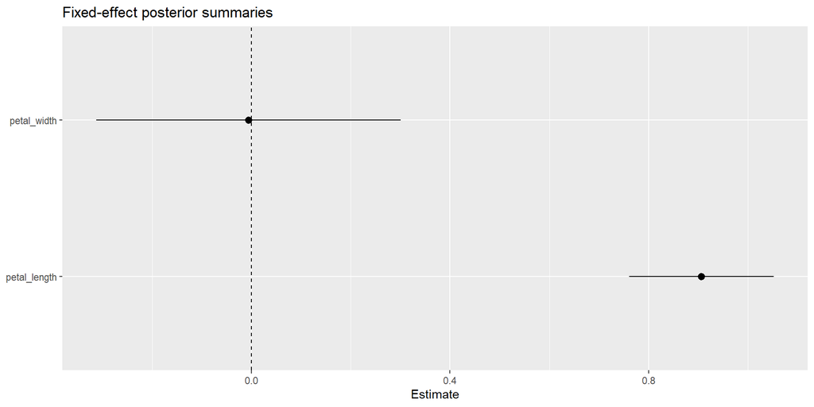

```r
tidy(result) |>
  ggplot(aes(x = term, y = estimate, ymin = conf.low, ymax = conf.high)) +
  geom_pointrange() +
  geom_hline(yintercept = 0, linetype = "dashed") +
  coord_flip() +
  labs(title = "Fixed-effect posterior summaries", x = NULL, y = "Estimate")
```

## `inlabru` integration with `tidy`

As of now (version 2.14.1.9005.+) `inlabru` also provides broom-style tidiers for `bru` model objects.

- `glance()` — one row of model-level fit summaries

returns a single-row tibble with the DIC, WAIC, marginal log-likelihood, the number of observations, and total wall-clock time.

```r
glance(result)
```

```
# A tibble: 1 × 5
    dic  waic marginal_loglik  nobs elapsed
  <dbl> <dbl>           <dbl> <int>   <dbl>
1  108.  109.           -86.4   150    1.67
```

Useful for model comparison

```r
cmp2 = ~ -1 +
  spp(Species, model = "iid", initial = -6, fixed = T) +
  petal_length(Petal.Length, model = "linear")

lik2 = bru_obs(formula = Sepal.Length ~ .,data = iris)

result2 = bru(cmp2, lik2)

bind_rows(
  glance(result2) %>%  mutate(model = "Species + Petal Length"),
  glance(result) %>% mutate(model = "Species + Petal Length + Petal Width")
) %>%
  select(model, dic, waic, marginal_loglik, nobs)
```

```
# A tibble: 2 × 5
  model                                  dic  waic marginal_loglik  nobs
  <chr>                                <dbl> <dbl>           <dbl> <int>
1 Species + Petal Length                106.  106.           -81.1   150
2 Species + Petal Length + Petal Width  108.  109.           -86.4   150
```

## `inlabru` integration with `tidy`

As of now (version 2.14.1.9005.+) `inlabru` also provides broom-style tidiers for `bru` model objects.

- `augment()` — original data extended with posterior fitted values

adds posterior summaries of the linear predictor to a data frame (or a prediction grid as we will see next). Note that you must supply a `pred_formula` that names what to predict

```r
grid <- expand.grid(Petal.Length = seq(1,6.9,0.1) ,
                 Species = c("setosa","versicolor","virginica"))

augmented <- augment(
  result2,
  data = iris,
  pred_formula = ~ spp + petal_length,
  n_samples = 500L,
  seed = 1L
)
```

```
# A tibble: 6 × 9
  Sepal.Length Sepal.Width Petal.Length Petal.Width Species .fitted .fitted_low
         <dbl>       <dbl>        <dbl>       <dbl> <fct>     <dbl>       <dbl>
1          5.1         3.5          1.4         0.2 setosa     4.95        4.86
2          4.9         3            1.4         0.2 setosa     4.95        4.86
3          4.7         3.2          1.3         0.2 setosa     4.86        4.77
4          4.6         3.1          1.5         0.2 setosa     5.04        4.94
5          5           3.6          1.4         0.2 setosa     4.95        4.86
6          5.4         3.9          1.7         0.4 setosa     5.22        5.12
# ℹ 2 more variables: .fitted_high <dbl>, .fitted_sd <dbl>
```

- `.fitted`: posterior mean
- `.fitted_low` `.fitted_high`: 2.5 % and 97.5 % quantiles
- `.fitted_sd`: posterior standard deviation.

## `inlabru` integration with `tidy`

As of now (version 2.14.1.9005.+) `inlabru` also provides broom-style tidiers for `bru` model objects.

- `augment()` — original data extended with posterior fitted values

adds posterior summaries of the linear predictor to a data frame (or a prediction grid as we will see next). Note that you must supply a `pred_formula` that names what to predict

```r
augmented <- augment(
  result2,
  data = iris,
  pred_formula = ~ spp + petal_length,
  n_samples = 500L,
  seed = 1L
)
```

What can you put on `pred_formula`?

- covariate can be accessed as `.data$x`
- the effect as `x` or `.effect$x`
- the latent variable as `x_latent` or `.latent$x`
- `augment()` $\rightarrow$ `predict()` $\rightarrow$ `generate()`

We can use `ggplot` to plot the fitted line with a credible bands:

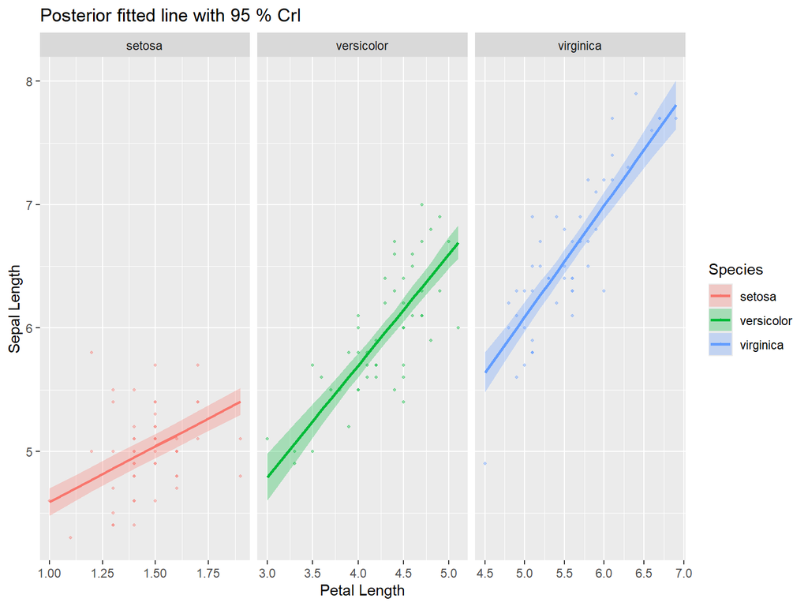

```r
ggplot() +
  geom_point(data = iris,
             aes(Petal.Length,
                 Sepal.Length,
                 color=Species),
             alpha = 0.4, size = 0.8) +
  geom_ribbon(
    data = augmented,
    aes(Petal.Length,
        ymin = .fitted_low,
        ymax = .fitted_high,
        fill=Species),
   , alpha = 0.3
  ) +
  geom_line(
    data = augmented,
    aes(Petal.Length,
        .fitted,colour=Species),
    , linewidth = 1
  ) +
  labs(
    title = "Posterior fitted line with 95 % CrI",
    x = "Petal Length", y = "Sepal Length"
  ) +
  facet_wrap(~Species,scales="free_x")
```

## `predict()` and `generate()` functions

Often one wants more “complex” results from the model.

Suppose we fit a model with the following linear predictor

$$\eta_i = \beta_{0,\text{Species}_i} + \beta_{1,\text{Species}_i}\text{Petal Length}_i,\ i =1,\dots,n$$

We might want to recover the three regression lines

- $\eta_i = \beta_{0,\text{Setosa}} + \beta_{1,\text{Setosa}}\text{Petal Length}_i$
- $\eta_i = \beta_{0,\text{Virginica}} + \beta_{1,\text{Virginica}}\text{Petal Length}_i$
- $\eta_i = \beta_{0,\text{Versicolor}} + \beta_{1,\text{Versicolor}}\text{Petal Length}_i$

To do this we can use the `predict()` and `generate()` functions.

- `predict()` *simulates* from the fitted posterior distribution $\pi(\mathbf{y}|\mathbf{u},\theta)$, computes what you ask and produces a summary of the samples (mean, sd, quantiles, etc)
- `generate()` *simulates* from the fitted posterior distribution $\pi(\mathbf{y}|\mathbf{u},\theta)$, computes what you ask and return the samples!

## Example 1

```r
cmp = ~ -1 + fixed_effects(~Species * Petal.Length, model = "fixed")

lik = bru_obs(formula = Sepal.Length ~ .,
              data = iris)

fit = bru(cmp, lik)

pred_grid <- iris %>%
  group_by(Species) %>%
  reframe(Petal.Length = seq(min(Petal.Length),
                             max(Petal.Length), by = 0.1))

res = predict(fit, pred_grid, ~ fixed_effects)

res[1:5,]
```

```
  Species Petal.Length     mean         sd   q0.025     q0.5   q0.975   median
1  setosa          1.0 4.808846 0.12847550 4.515430 4.808145 5.038056 4.808145
2  setosa          1.1 4.851472 0.10535855 4.599697 4.840281 5.033684 4.840281
3  setosa          1.2 4.894098 0.08357012 4.692597 4.890026 5.036542 4.890026
4  setosa          1.3 4.936724 0.06447148 4.790670 4.935365 5.046223 4.935365
5  setosa          1.4 4.979349 0.05116883 4.873126 4.980636 5.073340 4.980636
  mean.mc_std_err sd.mc_std_err
1     0.015091827   0.011221384
2     0.012356141   0.009101429
3     0.009776814   0.007099011
4     0.007525104   0.005389777
5     0.005969812   0.004264647
```

## Example 1

Notice that we predict only within the range of the covariate for each species:

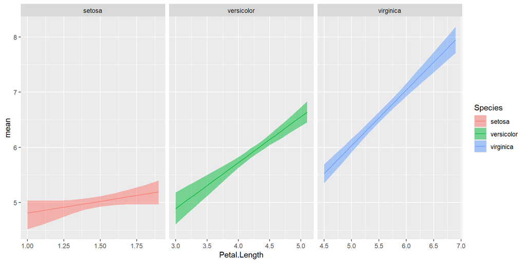

```r
res %>% ggplot() + geom_line(aes(Petal.Length, mean, group = Species, color = Species)) +
  geom_ribbon(aes(Petal.Length, ymin = q0.025 , ymax = q0.975,
                  group = Species, fill = Species), alpha = 0.5)+
  facet_wrap(~Species,scales="free_x")
```

## Example 2

```r
cmp = ~ -1 + beta0(Species, model = "iid", initial = -6, fixed = T) +
  beta1(Species, Petal.Length, model = "iid", initial = -6, fixed = T)


lik = bru_obs(formula = Sepal.Length ~ .,
              data = iris)

fit = bru(cmp, lik)

res = predict(fit, pred_grid, ~ beta0 + beta1)

res[1:5,]
```

```
  Species Petal.Length     mean         sd   q0.025     q0.5   q0.975   median
1  setosa          1.0 4.753028 0.13711904 4.485400 4.753146 4.984118 4.753146
2  setosa          1.1 4.808178 0.11144580 4.578509 4.812641 4.999713 4.812641
3  setosa          1.2 4.863329 0.08741597 4.669569 4.861557 5.025813 4.861557
4  setosa          1.3 4.918479 0.06682653 4.763269 4.911623 5.039318 4.911623
5  setosa          1.4 4.973629 0.05378537 4.867574 4.973953 5.061211 4.973953
  mean.mc_std_err sd.mc_std_err
1     0.015884607   0.010863513
2     0.012951293   0.009033565
3     0.010195120   0.007267617
4     0.007811219   0.005642833
5     0.006261378   0.004414204
```

## Example 2

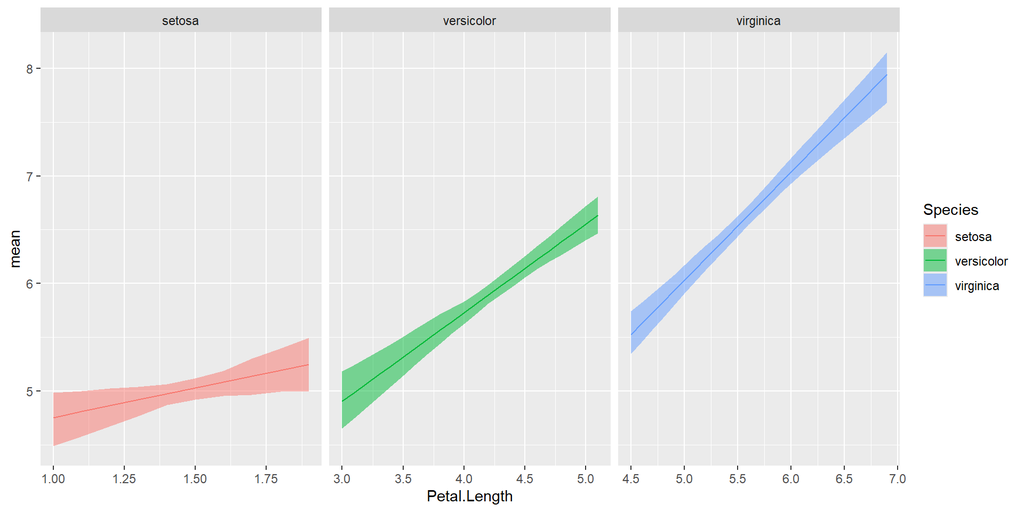

```r
res %>% ggplot() + geom_line(aes(Petal.Length, mean, group = Species, color = Species)) +
  geom_ribbon(aes(Petal.Length, ymin = q0.025 , ymax = q0.975,
                  group = Species, fill = Species), alpha = 0.5)+
  facet_wrap(~Species,scales="free_x")
```

## Yet another example

Let’s fit the model for the Tokyo rainfall data

$$\begin{aligned}
y_t|\eta_t&\sim\text{Bin}(n_t, p_t),\qquad i = 1,\dots,366\\
\eta_t &= \text{logit}(p_t)= \beta_0 + f(\text{time}_t)
\end{aligned}$$

```r
data("Tokyo")
cmp= ~ -1 + Intercept(1) + time(time, model ="rw2")
formula = y ~ Intercept + time
lik = bru_obs(formula = formula,
              data = Tokyo,
              Ntrials = n,
              family = "binomial")
fit = bru(cmp, lik)
```

We now want to extract results…what do we want?

- The time effect $f(\text{time}_t)$ ?
- The linear predictor $\eta_t = \beta_0 + f(\text{time}_t)$?
- The estimated probability off precipitation $p_t = \text{inv_logit}(\eta_t)$ ?

We can get all of them with the `predict()` or `generate()` functions!

## Example - `predict()`

```r
preds1 = predict(object = fit, newdata = Tokyo, ~ time)
preds2 = predict(object = fit, newdata = Tokyo, ~ Intercept + time)
inv_logit = function(x) ((1 + exp(-x))^(-1))
preds3 = predict(object = fit, newdata = Tokyo, ~ inv_logit(Intercept + time))
```

or

```r
inv_logit = function(x) ((1 + exp(-x))^(-1))
preds = predict( fit, newdata = Tokyo,
                ~ data.frame(time_eff = time,
                             lin_pred = Intercept + time,
                             probs = inv_logit(Intercept + time)),
                n.samples = 1000
                )
# preds is then a list
round(preds$probs[1:3,],3)
```

```
  y n time  mean    sd q0.025  q0.5 q0.975 median mean.mc_std_err sd.mc_std_err
1 0 2    1 0.174 0.087  0.056 0.157  0.386  0.157           0.003         0.003
2 0 2    2 0.171 0.082  0.058 0.155  0.371  0.155           0.003         0.003
3 1 2    3 0.169 0.078  0.062 0.154  0.358  0.154           0.003         0.003
```

## Example - `predict()`

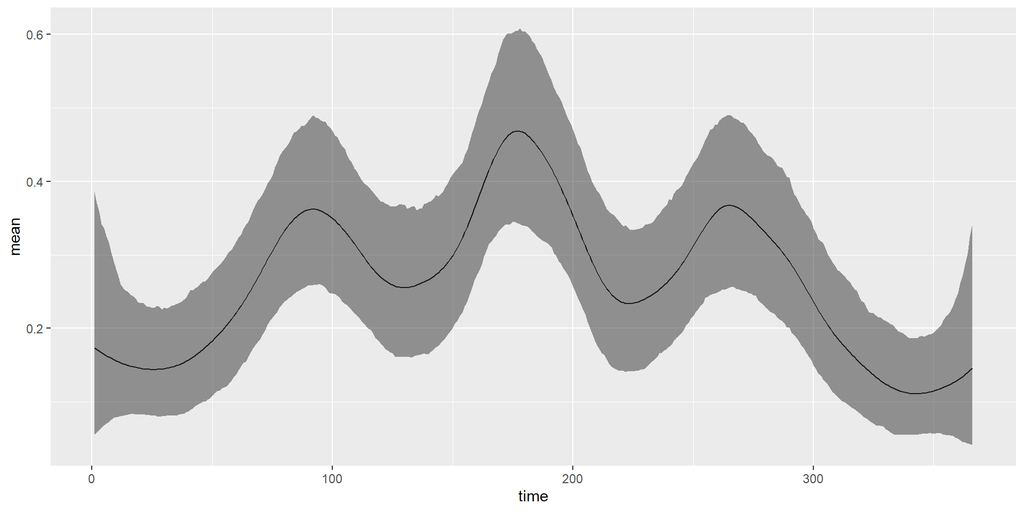

```r
preds$probs %>% ggplot() + geom_line(aes(time, mean)) +
  geom_ribbon(aes(time, ymin = q0.025, ymax = q0.975), alpha = 0.5)
```

## Example - `generate()`

```r
samples = generate(fit, newdata =  Tokyo, ~ data.frame(time_eff = time,
                             lin_pred = Intercept + time,
                             probs = inv_logit(Intercept + time)),
               n.samples = 20)


# samples is now a list of length 20 (n.samples) each element of the list looks like:

samples[[1]][1:3,]
```

```
    time_eff  lin_pred     probs
1 -0.8836288 -1.833218 0.1378553
2 -0.8997028 -1.849292 0.1359560
3 -0.9217866 -1.871376 0.1333826
```

## Example - `generate()`

```r
data.frame(time = Tokyo$time, sapply(samples, function(x) x$probs)) %>%
  pivot_longer(-time) %>%
  ggplot() + geom_line(aes(time, value, group = name, color = factor(name))) +
  theme(legend.position = "none")
```

[figure not shown]

# Manipulating posterior marginals

## Manipulating posterior marginals

We can be interested in functions of the posterior marginals that are computed by the `bru()` function.

For example, we might want to :

- compute the mean of a posterior marginal
- compute the median of a posterior marginal
- sample from the posterior marginal
- …

All this can be done with the help of the `inla.*marginal()` family of functions

## Example from the Tokyo example

```r
post_prec = fit$marginals.hyperpar$`Precision for time`
post_sd = inla.tmarginal(fun = function(x)
                          1/sqrt(x),
                         post_prec)
post_sd_mode = inla.mmarginal(post_sd)
post_sd_mean = inla.emarginal(fun =function(x)x, post_sd )
post_sd_sample = inla.rmarginal(1000, post_sd)
```

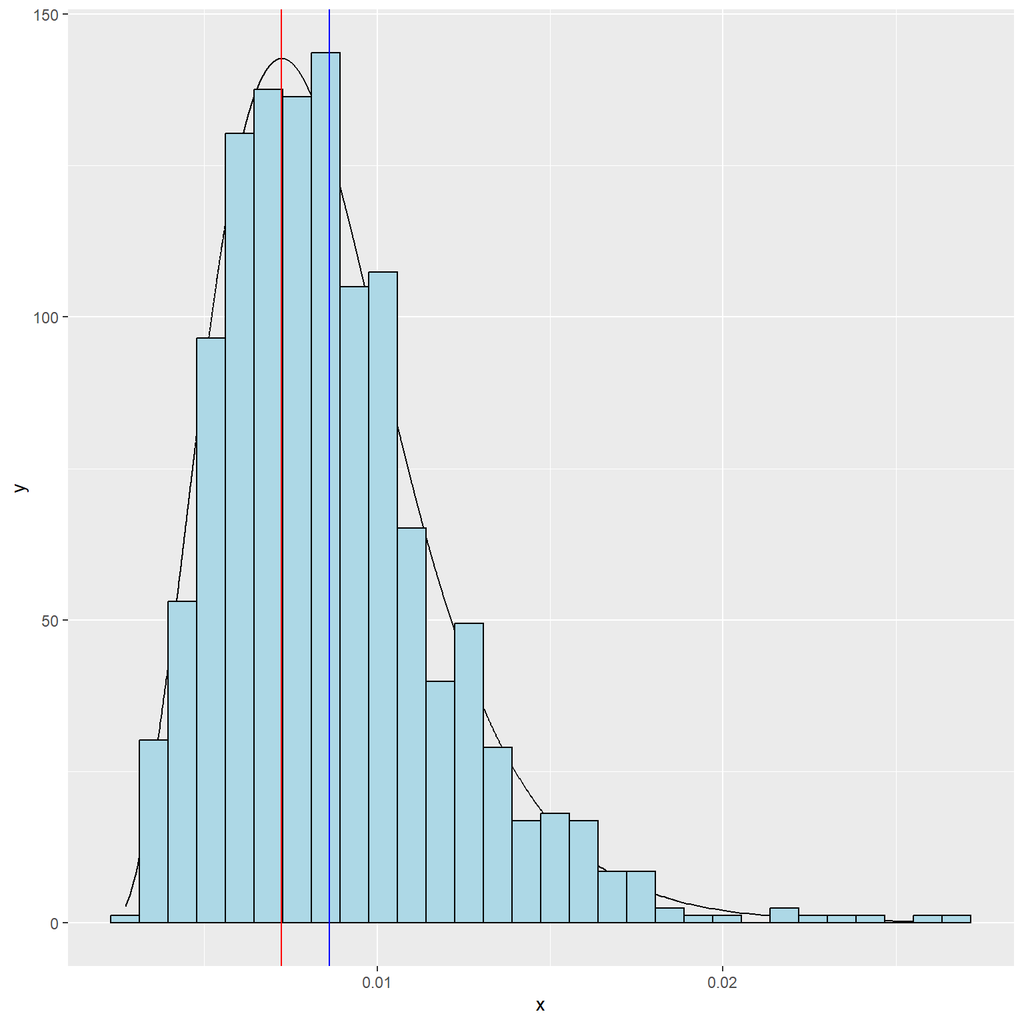

```r
ggplot() + geom_line(data = post_sd, aes(x,y))  +
  geom_histogram(data = data.frame(samples = post_sd_sample),
                 aes(x = samples, y = after_stat(density)),
                 color = "black", fill = "lightblue")+
  geom_vline(xintercept = post_sd_mode, color = "red") +
    geom_vline(xintercept = post_sd_mean, color = "blue")
```

## The `inla.*marginal()` family

| **Function Name** | **Usage** |
| --- | --- |
| `inla.dmarginal(x, marginal, ...)` | Density at a vector of evaluation points $x$ |
| `inla.pmarginal(q, marginal, ...)` | Distribution function at a vector of quantiles *q* |
| `inla.qmarginal(p, marginal, ...)` | Quantile function at a vector of probabilities *p* |
| `inla.rmarginal(n, marginal)` | Generate *n* random deviates |
| `inla.hpdmarginal(p, marginal, ...)` | Compute the highest posterior density interval at level *p* |
| `inla.emarginal(fun, marginal, ...)` | Compute the expected value assuming transformation given by *fun* |
| `inla.mmarginal(marginal)` | Computes the mode |
| `inla.smarginal(marginal, ...)` | Smoothed density (returns x-values and interpolated y-values) |
| `inla.tmarginal(fun, marginal, ...)` | Transform the marginal using function *fun* |
| `inla.zmarginal(marginal)` | Summary statistics for the marginal |

# Getting help while using `inlabru`

## Which priors have I used?

You might wonder which priors have you used in your model..

```r
fit = bru(cmp, lik)

INLA::inla.priors.used(fit)
```

**NB** `inla.priors.used` is a function of the `INLA` package, so you need to load it explicitly.

## Getting help!

The `inla.doc()` function provides help on the different prior, latent models and likelihood.

```r
inla.doc("ar1")
inla.doc("pc.prior")
inla.doc("gaussian")
```

## Which models are implemented?

**Likelihoods**

```r
# which likelihoods?
inla.list.models("likelihood")
```

```
Section [likelihood]
     0binomial                     New 0-inflated Binomial
     0binomialS                    New 0-inflated Binomial Swap
     0nbinomial                    New 0-inflated nBinomial
     0nbinomialS                   New 0-inflated nBinomialS
     0poisson                      New 0-inflated Poisson
     0poissonS                     New 0-inflated Poisson Swap
     1poisson                      New 1-inflated Poisson
     1poissonS                     New 1-inflated Poisson Swap
     agaussian                     The aggregated Gaussian likelihoood
     bcgaussian                    The Box-Cox Gaussian likelihoood
     bell                          The Bell likelihood
     beta                          The Beta likelihood
     betabinomial                  The Beta-Binomial likelihood
     betabinomialna                The Beta-Binomial Normal approximation likelihood
     bgev                          The blended Generalized Extreme Value likelihood
     binomial                      The Binomial likelihood
     binomialmix                   Binomial mixture
     cbinomial                     The clustered Binomial likelihood
     cennbinomial2                 The CenNegBinomial2 likelihood (similar to cenpoisson2)
     cenpoisson                    Then censored Poisson likelihood
     cenpoisson2                   Then censored Poisson likelihood (version 2)
     circularnormal                The circular Gaussian likelihoood
     cloglike                      User-defined likelihood
     coxph                         Cox-proportional hazard likelihood
     dgompertzsurv                 destructive gompertz (survival) distribution
     dgp                           Discrete generalized Pareto likelihood
     egp                           Exteneded Generalized Pareto likelihood
     exponential                   The Exponential likelihood
     exponentialsurv               The Exponential likelihood (survival)
     exppower                      The exponential power likelihoood
     fl                            The fl likelihood
     fmri                          fmri distribution (special nc-chi)
     fmrisurv                      fmri distribution (special nc-chi)
     gamma                         The Gamma likelihood
     gammacount                    A Gamma generalisation of the Poisson likelihood
     gammacountmean                Another Gamma generalisation of the Poisson likelihood
     gammajw                       A special case of the Gamma likelihood
     gammajwsurv                   A special case of the Gamma likelihood (survival)
     gammasurv                     The Gamma likelihood (survival)
```

[output cut: 60 more lines]

```
     zeroinflatedbinomial0         Zero-inflated Binomial, type 0
     zeroinflatedbinomial1         Zero-inflated Binomial, type 1
     zeroinflatedbinomial2         Zero-inflated Binomial, type 2
     zeroinflatedcenpoisson0       Zero-inflated censored Poisson, type 0
     zeroinflatedcenpoisson1       Zero-inflated censored Poisson, type 1
     zeroinflatednbinomial0        Zero inflated negBinomial, type 0
     zeroinflatednbinomial1        Zero inflated negBinomial, type 1
     zeroinflatednbinomial1strata2 Zero inflated negBinomial, type 1, strata 2
     zeroinflatednbinomial1strata3 Zero inflated negBinomial, type 1, strata 3
     zeroinflatednbinomial2        Zero inflated negBinomial, type 2
     zeroinflatedpoisson0          Zero-inflated Poisson, type 0
     zeroinflatedpoisson1          Zero-inflated Poisson, type 1
     zeroinflatedpoisson2          Zero-inflated Poisson, type 2
     zeroninflatedbinomial2        Zero and N inflated binomial, type 2
     zeroninflatedbinomial3        Zero and N inflated binomial, type 3
```

## Which models are implemented?

**Components**

```r
# which latent models? (components)
inla.list.models("latent")
```

```
Section [latent]
     2diid                         (This model is obsolute)
     ar                            Auto-regressive model of order p (AR(p))
     ar1                           Auto-regressive model of order 1 (AR(1))
     ar1c                          Auto-regressive model of order 1 w/covariates
     besag                         The Besag area model (CAR-model)
     besag2                        The shared Besag model
     besagproper                   A proper version of the Besag model
     besagproper2                  An alternative proper version of the Besag model
     bym                           The BYM-model (Besag-York-Mollier model)
     bym2                          The BYM-model with the PC priors
     cgeneric                      Generic latent model specified using C
     clinear                       Constrained linear effect
     copy                          Create a copy of a model component
     crw2                          Exact solution to the random walk of order 2
     dmatern                       Dense Matern field
     fgn                           Fractional Gaussian noise model
     fgn2                          Fractional Gaussian noise model (alt 2)
     generic                       A generic model
     generic0                      A generic model (type 0)
     generic1                      A generic model (type 1)
     generic2                      A generic model (type 2)
     generic3                      A generic model (type 3)
     iid                           Gaussian random effects in dim=1
     iid1d                         Gaussian random effect in dim=1 with Wishart prior
     iid2d                         Gaussian random effect in dim=2 with Wishart prior
     iid3d                         Gaussian random effect in dim=3 with Wishart prior
     iid4d                         Gaussian random effect in dim=4 with Wishart prior
     iid5d                         Gaussian random effect in dim=5 with Wishart prior
     iidkd                         Gaussian random effect in dim=k with Wishart prior
     intslope                      Intecept-slope model with Wishart-prior
     linear                        Alternative interface to an fixed effect
     log1exp                       A nonlinear model of a covariate
     logdist                       A nonlinear model of a covariate
     matern2d                      Matern covariance function on a regular grid
     meb                           Berkson measurement error model
     mec                           Classical measurement error model
     ou                            The Ornstein-Uhlenbeck process
     prw2                          Proper random walk of order 2
     revsigm                       Reverse sigmoidal effect of a covariate
     rgeneric                      Generic latent model specified using R
     rw1                           Random walk of order 1
     rw2                           Random walk of order 2
     rw2d                          Thin-plate spline model
     rw2diid                       Thin-plate spline with iid noise
     scopy                         Create a scopy of a model component
     seasonal                      Seasonal model for time series
     sigm                          Sigmoidal effect of a covariate
     slm                           Spatial lag model
     spde                          A SPDE model
     spde2                         A SPDE2 model
     spde3                         A SPDE3 model
     z                             The z-model in a classical mixed model formulation
```

## Which models are implemented?

**Priors**

```r
# which priors?
inla.list.models("prior")
```

```
Section [prior]
     betacorrelation               Beta prior for the correlation
     dirichlet                     Dirichlet prior
     expression:                   A generic prior defined using expressions
     flat                          A constant prior
     gamma                         Gamma prior
     gaussian                      Gaussian prior
     invalid                       Void prior
     jeffreystdf                   Jeffreys prior for the doc
     laplace                       Laplace prior
     linksnintercept               Skew-normal-link intercept-prior
     logflat                       A constant prior for log(theta)
     loggamma                      Log-Gamma prior
     logiflat                      A constant prior for log(1/theta)
     logitbeta                     Logit prior for a probability
     logtgaussian                  Truncated Gaussian prior
     logtnormal                    Truncated Normal prior
     minuslogsqrtruncnormal        (obsolete)
     mvnorm                        A multivariate Normal prior
     none                          No prior
     normal                        Normal prior
     pc                            Generic PC prior
     pc.alphaw                     PC prior for alpha in Weibull
     pc.ar                         PC prior for the AR(p) model
     pc.cor0                       PC prior correlation, basemodel cor=0
     pc.cor1                       PC prior correlation, basemodel cor=1
     pc.dof                        PC prior for log(dof-2)
     pc.egptail                    PC prior for the tail in the EGP likelihood
     pc.fgnh                       PC prior for the Hurst parameter in FGN
     pc.gamma                      PC prior for a Gamma parameter
     pc.gammacount                 PC prior for the GammaCount likelihood
     pc.gevtail                    PC prior for the tail in the GEV likelihood
     pc.matern                     PC prior for the Matern SPDE
     pc.mgamma                     PC prior for a Gamma parameter
     pc.prec                       PC prior for log(precision)
     pc.prw2.range                 PCprior for the range in PRW2
     pc.range                      PC prior for the range in the Matern SPDE
     pc.sn                         PC prior for the skew-normal
     pc.spde.GA                    (experimental)
     pom                           #classes-dependent prior for the POM model
     ref.ar                        Reference prior for the AR(p) model, p<=3
     rprior:                       A R-function defining the prior
     table:                        A generic tabulated prior
     wishart1d                     Wishart prior dim=1
     wishart2d                     Wishart prior dim=2
     wishart3d                     Wishart prior dim=3
     wishart4d                     Wishart prior dim=4
     wishart5d                     Wishart prior dim=5
     wishartkd                     Wishart prior
```

# Take home message